# Assignment 1

# PART I: Working with Regular Expressions

## 1. Based on the words dataset in the stringr package, use regular expressions to list all words that:

```r
library(stringr)
library(tidyverse)
library(tidytext)
library(wordcloud2)
library(forcats)
```

### a. Start with the letter “w”. For example, “who”.

```r
str_subset(words, "^w")
```

```
##  [1] "wage"      "wait"      "walk"      "wall"      "want"      "war"
##  [7] "warm"      "wash"      "waste"     "watch"     "water"     "way"
## [13] "we"        "wear"      "wednesday" "wee"       "week"      "weigh"
## [19] "welcome"   "well"      "west"      "what"      "when"      "where"
## [25] "whether"   "which"     "while"     "white"     "who"       "whole"
## [31] "why"       "wide"      "wife"      "will"      "win"       "wind"
## [37] "window"    "wish"      "with"      "within"    "without"   "woman"
## [43] "wonder"    "wood"      "word"      "work"      "world"     "worry"
## [49] "worse"     "worth"     "would"     "write"     "wrong"
```

### b. End with the letter “t”. For example, “commit”.

```r
str_subset(words, "t$")
```

```
##   [1] "about"       "accept"      "account"     "act"         "admit"
##   [6] "affect"      "against"     "agent"       "almost"      "alright"
##  [11] "amount"      "apart"       "apparent"    "appoint"     "art"
##  [16] "at"          "beat"        "benefit"     "best"        "bet"
##  [21] "bit"         "boat"        "brilliant"   "budget"      "but"
##  [26] "cat"         "cent"        "Christ"      "client"      "collect"
##  [31] "comment"     "commit"      "consult"     "contact"     "contract"
##  [36] "correct"     "cost"        "count"       "court"       "current"
##  [41] "cut"         "department"  "difficult"   "direct"      "district"
##  [46] "document"    "doubt"       "east"        "eat"         "effect"
##  [51] "eight"       "elect"       "environment" "exact"       "except"
##  [56] "exist"       "expect"      "fact"        "fast"        "fight"
##  [61] "first"       "fit"         "flat"        "foot"        "forget"
##  [66] "front"       "get"         "grant"       "great"       "heart"
##  [71] "heat"        "hit"         "honest"      "hot"         "important"
##  [76] "interest"    "invest"      "it"          "just"        "last"
##  [81] "left"        "let"         "light"       "limit"       "list"
##  [86] "lot"         "market"      "meet"        "might"       "moment"
##  [91] "most"        "must"        "next"        "night"       "not"
##  [96] "ought"       "out"         "paint"       "parent"      "part"
## [101] "past"        "percent"     "perfect"     "point"       "post"
## [106] "present"     "print"       "product"     "project"     "protect"
## [111] "put"         "quiet"       "recent"      "report"      "represent"
## [116] "respect"     "rest"        "result"      "right"       "seat"
## [121] "set"         "sheet"       "shoot"       "short"       "shut"
## [126] "sit"         "slight"      "sort"        "start"       "straight"
## [131] "street"      "student"     "subject"     "suggest"     "suit"
## [136] "support"     "test"        "tonight"     "transport"   "treat"
## [141] "trust"       "unit"        "visit"       "wait"        "want"
## [146] "west"        "what"        "without"     "yet"
```

### c. Have a capital letter. For example, “Christ”.

```r
str_subset(words, "[A-Z]")
```

```
## [1] "Christ"    "Christmas"
```

### d. Start with the letter “w” and end with the letter “t”. For example,“want”.

```r
str_subset(words, "^w.*t$")
```

```
## [1] "wait"    "want"    "west"    "what"    "without"
```

### e. Are exactly three letters long. For example, “kid”.

```r
str_subset(words, "^[a-z]{3}$")
```

```
##   [1] "act" "add" "age" "ago" "air" "all" "and" "any" "arm" "art" "ask" "bad"
##  [13] "bag" "bar" "bed" "bet" "big" "bit" "box" "boy" "bus" "but" "buy" "can"
##  [25] "car" "cat" "cup" "cut" "dad" "day" "die" "dog" "dry" "due" "eat" "egg"
##  [37] "end" "eye" "far" "few" "fit" "fly" "for" "fun" "gas" "get" "god" "guy"
##  [49] "hit" "hot" "how" "job" "key" "kid" "lad" "law" "lay" "leg" "let" "lie"
##  [61] "lot" "low" "man" "may" "mrs" "new" "non" "not" "now" "odd" "off" "old"
##  [73] "one" "out" "own" "pay" "per" "put" "red" "rid" "run" "say" "see" "set"
##  [85] "sex" "she" "sir" "sit" "six" "son" "sun" "tax" "tea" "ten" "the" "tie"
##  [97] "too" "top" "try" "two" "use" "war" "way" "wee" "who" "why" "win" "yes"
## [109] "yet" "you"
```

### f. Start and end with the same letter. For example, “dead”.

```r
str_subset(words, "^(.).*\\1$")
```

```
##  [1] "america"    "area"       "dad"        "dead"       "depend"
##  [6] "educate"    "else"       "encourage"  "engine"     "europe"
## [11] "evidence"   "example"    "excuse"     "exercise"   "expense"
## [16] "experience" "eye"        "health"     "high"       "knock"
## [21] "level"      "local"      "nation"     "non"        "rather"
## [26] "refer"      "remember"   "serious"    "stairs"     "test"
## [31] "tonight"    "transport"  "treat"      "trust"      "window"
## [36] "yesterday"
```

## 2. Based on the fruit dataset in the stringr package, use regular expressions to list all fruits with names that:

### a. Have exactly two occurrences of the letter “p” next to each other. For example, “bell pepper”.

```r
str_subset(fruit, "pp")
```

```
## [1] "apple"        "bell pepper"  "chili pepper" "pineapple"
```

### b. Have only two occurrences of the letter “p” anywhere in the name. For example, “papaya”.

```r
str_subset(fruit, "^(?:[^p]*p[^p]*){2}$")
```

```
## [1] "apple"             "papaya"            "purple mangosteen"
```

### c. Start with three consonants. For example, “lychee”.

```r
str_subset(fruit, "^[^aeiou]{3}")
```

```
## [1] "lychee"     "physalis"   "strawberry"
```

# PART II: Working with Yelp Restaurant Review Data

##### Given the customer review data for the Evil Czech Brewery and Public House which is available at https://s3.amazonaws.com/notredame.analytics.data/evilczechreviews.csv, perform the following tasks:

### 1. Import the data and call it ecReviews. Use the glimpse() command to show that your import was successful.

```r
ecReviews <-  read.csv("https://s3.amazonaws.com/notredame.analytics.data/evilczechreviews.csv")
glimpse(ecReviews)
```

```
## Rows: 675
## Columns: 8
## $ reviewDate  <chr> "8/24/2020", "8/22/2020", "8/9/2020", "8/22/2020", "8/21/2…
## $ rating      <int> 5, 5, 5, 5, 5, 5, 4, 4, 4, 2, 5, 4, 5, 5, 3, 1, 5, 5, 4, 4…
## $ review      <chr> "First time for me to dine at this restaurant. We went in …
## $ author      <chr> "Christopher F.", "DeeDee A.", "Claire B.", "Krista G.", "…
## $ location    <chr> "Indianapolis, IN", "Triangle, VA", "New York, NY", "Three…
## $ friends     <int> 626, 360, 46, 22, 35, 0, 0, 25, 1, 80, 1, 6, 367, 140, 120…
## $ elite       <int> 2020, NA, NA, NA, NA, NA, NA, NA, NA, NA, NA, NA, 2020, 20…
## $ reviewCount <int> 267, 22, 34, 66, 24, 10, 15, 35, 6, 23, 8, 23, 213, 163, 5…
```

### 2. Using the tidy text approach, tokenize ecReviews by words. Use the head() command to preview the tokenized ecReviews tibble.

```r
token_reviews <- ecReviews %>%
  unnest_tokens(output=word, input=review, token="words")
head(token_reviews)
```

|  | reviewDate | rating | author | location | friends | elite | reviewCount | word |
| --- | --- | --- | --- | --- | --- | --- | --- | --- |
| 1 | 8/24/2020 | 5 | Christopher F. | Indianapolis, IN | 626 | 2020 | 267 | first |
| 2 | 8/24/2020 | 5 | Christopher F. | Indianapolis, IN | 626 | 2020 | 267 | time |
| 3 | 8/24/2020 | 5 | Christopher F. | Indianapolis, IN | 626 | 2020 | 267 | for |
| 4 | 8/24/2020 | 5 | Christopher F. | Indianapolis, IN | 626 | 2020 | 267 | me |
| 5 | 8/24/2020 | 5 | Christopher F. | Indianapolis, IN | 626 | 2020 | 267 | to |
| 6 | 8/24/2020 | 5 | Christopher F. | Indianapolis, IN | 626 | 2020 | 267 | dine |

### 3. Create a custom stop words dictionary called custom_stop_words by adding numbers and meaningless tokens (limit to tokens with 3 letters or less) such as “amp” and “br” to the default stop words dictionary provided by the tidytext package. Use the head() command to preview the first 20 words in the custom dictionary.

```r
cust_words_nums <- c('1','2','3','4','5','6','7','8','9','0','ve','didn','don','II','set', 'amp', 'br', 'gt', '39', '34','bit', 'tgi', '19', '4.00', '3rd')
cust_words_2 <- token_reviews %>% filter(nchar(word)<=3)

custom_stop_words <- bind_rows(tibble(word= cust_words_nums, lexicon=c("custom")), stop_words, tibble(word=cust_words_2$word, lexicon=c("custom")))

head(custom_stop_words, 20)
```

| word | lexicon |
| --- | --- |
| 1 | custom |
| 2 | custom |
| 3 | custom |
| 4 | custom |
| 5 | custom |
| 6 | custom |
| 7 | custom |
| 8 | custom |
| 9 | custom |
| 0 | custom |

[output cut: 10 more lines]

### 4. Remove stop words from ecReviews using your custom dictionary

```r
token_reviews <- token_reviews %>%
  anti_join(custom_stop_words, by='word')

head(token_reviews, 20)
```

|  | reviewDate | rating | author | location | friends | elite | reviewCount | word |
| --- | --- | --- | --- | --- | --- | --- | --- | --- |
| 1 | 8/24/2020 | 5 | Christopher F. | Indianapolis, IN | 626 | 2020 | 267 | time |
| 2 | 8/24/2020 | 5 | Christopher F. | Indianapolis, IN | 626 | 2020 | 267 | dine |
| 3 | 8/24/2020 | 5 | Christopher F. | Indianapolis, IN | 626 | 2020 | 267 | restaurant |
| 4 | 8/24/2020 | 5 | Christopher F. | Indianapolis, IN | 626 | 2020 | 267 | brunch |
| 5 | 8/24/2020 | 5 | Christopher F. | Indianapolis, IN | 626 | 2020 | 267 | prior |
| 6 | 8/24/2020 | 5 | Christopher F. | Indianapolis, IN | 626 | 2020 | 267 | pandemic |
| 7 | 8/24/2020 | 5 | Christopher F. | Indianapolis, IN | 626 | 2020 | 267 | guidelines |
| 8 | 8/24/2020 | 5 | Christopher F. | Indianapolis, IN | 626 | 2020 | 267 | enjoyed |
| 9 | 8/24/2020 | 5 | Christopher F. | Indianapolis, IN | 626 | 2020 | 267 | brandon |
| 10 | 8/24/2020 | 5 | Christopher F. | Indianapolis, IN | 626 | 2020 | 267 | server |

[output cut: 10 more lines]

### 5. Create a visualization of the 5 most frequently occurring words in ecReviews for each rating.

This visualization includes instances of ties within the top 5 words used per rating

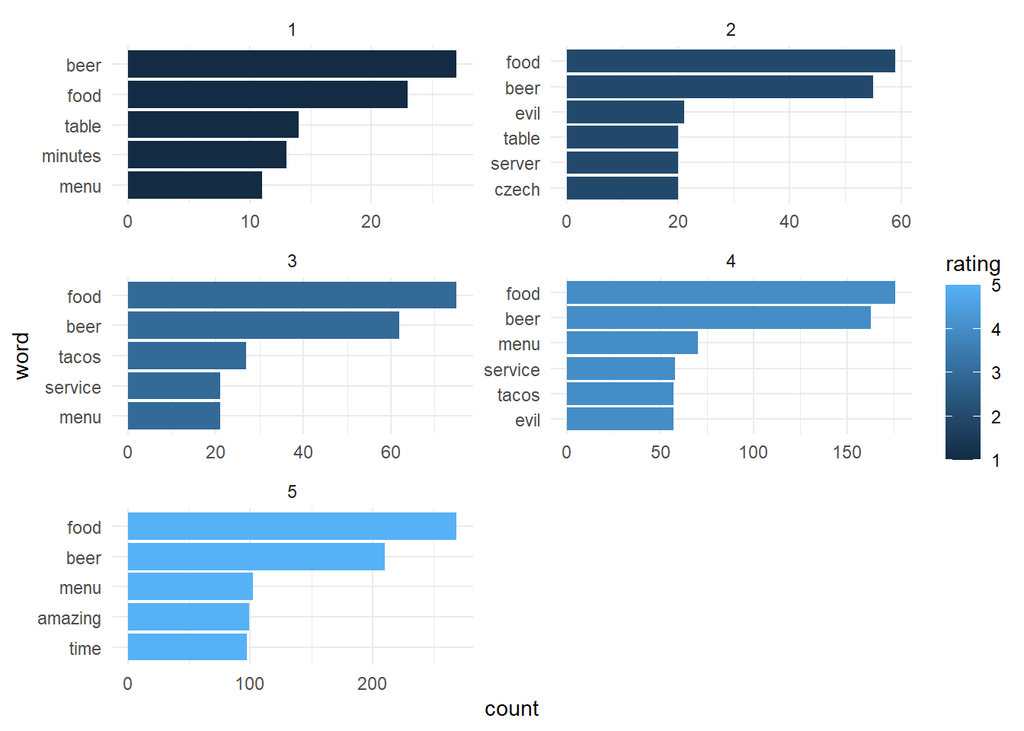

```r
token_reviews %>%
  count(rating, word) %>%
  group_by(rating) %>%
  top_n(5, n) %>%
  ungroup() %>%
  ggplot(mapping=aes(x=reorder_within(word, n, rating), y= n, fill=rating))+
  geom_col()+
  labs(x="word", y= "count")+
  facet_wrap(~rating, ncol=2, scales="free")+
  coord_flip()+
  scale_x_reordered()+
  theme_minimal()
```

### 6. Create another visualization of the top 5 words in ecReviews based on tf-idf for each rating.

This visualization includes instances of ties within the top 5 words used per rating by tf_idf.

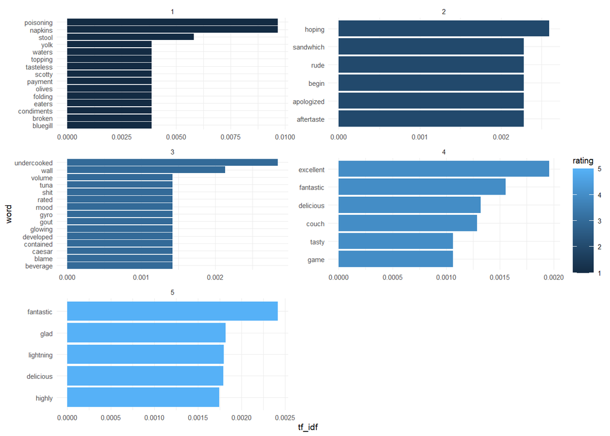

```r
token_reviews %>%
  count(rating, word) %>%
  bind_tf_idf(word, rating, n) %>%
  group_by(rating) %>%
  top_n(5,tf_idf) %>%
  ungroup() %>%
  ggplot(mapping=aes(x=reorder_within(word, tf_idf, rating), y= tf_idf, fill=rating))+
  geom_col()+
  labs(x="word", y= "tf_idf")+
  facet_wrap(~rating, ncol=2, scales="free", shrink=FALSE)+
  coord_flip()+
  scale_x_reordered()+
  theme_minimal(base_size = 7)
```